# A2 ASSIGNMENT - FOREX ARBITRAGE

Team 4

02/28/2025

# Load necessary libraries

Loading necessary libraries to perform the currency arbitrage analysis

```r
library(dplyr)
```

```r
library(ggplot2)
```

# Initial investment

Inputting the initial investment of USD$100,000

```r
Q <- 100000
```

# Fixed exchange rates

Plugging in the fixed exchange rates for the currency exchange arbitrage

```r
# Fixed exchange rates
exchange_rates <- list(
  "USD_to_CAD" = 1.43,
  "USD_to_EUR" = 0.95,
  "EUR_to_CAD" = 1.50
)
exchange_rates
```

```
## $USD_to_CAD
## [1] 1.43
##
## $USD_to_EUR
## [1] 0.95
##
## $EUR_to_CAD
## [1] 1.5
```

# Function to compute arbitrage opportunities for a given spread (0% to 1%)

This function calculates arbitrage opportunities by adjusting exchange rates based on a given spread (0% to 1%) and simulating currency conversions along predefined trading paths. It defines two arbitrage paths—one cycling through USD, CAD, and EUR, and the other through USD, EUR, and CAD—using the adjusted rates to compute the final amount after completing the cycle. The function then records the profit or loss for each path at the given spread and returns a data frame summarizing the results.

```r
# Function to compute arbitrage opportunities for a given spread (0% to 1%)
calculate_arbitrage <- function(spread) {

  # Adjusted exchange rates with spread
  adjusted_rates <- list(
    "USD_to_CAD" = exchange_rates$USD_to_CAD * (1 - spread),
    "USD_to_EUR" = exchange_rates$USD_to_EUR * (1 - spread),
    "EUR_to_CAD" = exchange_rates$EUR_to_CAD * (1 - spread),
    "CAD_to_USD" = (1 / exchange_rates$USD_to_CAD) * (1 - spread),
    "EUR_to_USD" = (1 / exchange_rates$USD_to_EUR) * (1 - spread),
    "CAD_to_EUR" = (1 / exchange_rates$EUR_to_CAD) * (1 - spread)
  )

  # Define arbitrage paths
  paths <- list(
    "USD -> CAD -> EUR -> USD" = function(Q) {
      Q_CAD <- Q * adjusted_rates$USD_to_CAD
      Q_EUR <- Q_CAD * adjusted_rates$CAD_to_EUR
      Q_USD <- Q_EUR * adjusted_rates$EUR_to_USD
      return(Q_USD)
    },
    "USD -> EUR -> CAD -> USD" = function(Q) {
      Q_EUR <- Q * adjusted_rates$USD_to_EUR
      Q_CAD <- Q_EUR * adjusted_rates$EUR_to_CAD
      Q_USD <- Q_CAD * adjusted_rates$CAD_to_USD
      return(Q_USD)
    }
  )

  # Store results
  results <- list()

  for (path in names(paths)) {
    final_amount <- paths[[path]](Q)
    profit <- final_amount - Q
    results[[length(results) + 1]] <- data.frame(
      Spread = spread * 100,  # Convert to percentage
      Path = path,
      Profit = profit
    )
  }

  return(do.call(rbind, results))
}
```

# Run calculations for spreads from 0% to 1% in steps of 0.1% (0.001)

The spread values are being inputted into the code to account for the change in profit as the volatility of currency increases. The code will also run the spread on each paths (Path 1 and Path 2) with an increment of 0.1%.

```r
spread_values <- seq(0.000, 0.010, by = 0.001)
arbitrage_results <- do.call(rbind, lapply(spread_values, calculate_arbitrage))
```

# Display the computed results (only profit)

Printing the arbitrage results of currency exchange for each path

```r
arbitrage_results <- arbitrage_results %>% select(Spread, Path, Profit)
print (arbitrage_results)
```

```
##    Spread                     Path      Profit
## 1     0.0 USD -> CAD -> EUR -> USD   350.87719
## 2     0.0 USD -> EUR -> CAD -> USD  -349.65035
## 3     0.1 USD -> CAD -> EUR -> USD    50.12551
## 4     0.1 USD -> EUR -> CAD -> USD  -648.30255
## 5     0.2 USD -> CAD -> EUR -> USD  -250.02466
## 6     0.2 USD -> EUR -> CAD -> USD  -946.35744
## 7     0.3 USD -> CAD -> EUR -> USD  -549.57394
## 8     0.3 USD -> EUR -> CAD -> USD -1243.81563
## 9     0.4 USD -> CAD -> EUR -> USD  -848.52291
## 10    0.4 USD -> EUR -> CAD -> USD -1540.67771
## 11    0.5 USD -> CAD -> EUR -> USD -1146.87219
## 12    0.5 USD -> EUR -> CAD -> USD -1836.94427
## 13    0.6 USD -> CAD -> EUR -> USD -1444.62238
## 14    0.6 USD -> EUR -> CAD -> USD -2132.61593
## 15    0.7 USD -> CAD -> EUR -> USD -1741.77407
## 16    0.7 USD -> EUR -> CAD -> USD -2427.69327
## 17    0.8 USD -> CAD -> EUR -> USD -2038.32787
## 18    0.8 USD -> EUR -> CAD -> USD -2722.17690
## 19    0.9 USD -> CAD -> EUR -> USD -2334.28438
## 20    0.9 USD -> EUR -> CAD -> USD -3016.06740
## 21    1.0 USD -> CAD -> EUR -> USD -2629.64421
## 22    1.0 USD -> EUR -> CAD -> USD -3309.36538
```

# Plot: Profit vs. Spread for Both Paths

Using ggplot to visualize the change in profit with an equal increment in spread

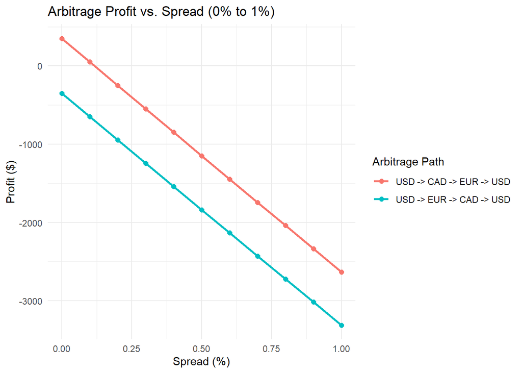

```r
ggplot(arbitrage_results, aes(x = Spread, y = Profit, color = Path)) +
  geom_line(size = 1) +
  geom_point(size = 2) +
  theme_minimal() +
  labs(title = "Arbitrage Profit vs. Spread (0% to 1%)",
       x = "Spread (%)",
       y = "Profit ($)",
       color = "Arbitrage Path")
```